# Part_I_Exploration_Template_1_Proj_III

### Project_III - Loan Data Exploratory & Explanatory Analysis

**By ThankGod Agada**

1. Introduction
2. Preliminary Wrangling
3. Univariate Exploration
4. Bivariate Exploration
5. Multivariate Exploration
6. Conclusion

#### 1. Introduction

This project is an Explorative and Explanative analysis of a Loan data set provided by Udacity. The dataset for this project consists of 113,937 loan records with 81 variables. Some of the key variables include Loan Amount, Borrower Income, and Loan Term amongst many others.

To understand the complete variables, here is the [data dictionary](https://docs.google.com/spreadsheets/u/0/d/1gDyi_L4UvIrLTEC6Wri5nbaMmkGmLQBk-Yx3z0XDEtI/edit?usp=sharing)

- **Import Libraries and Software needed to Wrangle and Visualize Data**

```python
#To Suppress warnings from final output
import warnings
warnings.simplefilter("ignore")

#Import all packages and set plots to be embedded inline
import pandas as pd
import numpy as np
import matplotlib.pyplot as plt
import seaborn as sb
%matplotlib inline
```

#### 2. Preliminary Wrangling

- **Directly downloaded loan dataset (ProsperLoanData.csv)**

```python
#To Load the dataset into pandas dataframe using pd.read_csv() function
loan_df = pd.read_csv('ProsperLoanData.csv')
```

```python
#To confirm operation
loan_df
```

|  | ListingKey | ListingNumber | ListingCreationDate | CreditGrade | Term | LoanStatus | ClosedDate | BorrowerAPR | BorrowerRate | LenderYield | ... | LP_ServiceFees | LP_CollectionFees | LP_GrossPrincipalLoss | LP_NetPrincipalLoss | LP_NonPrincipalRecoverypayments | PercentFunded | Recommendations | InvestmentFromFriendsCount | InvestmentFromFriendsAmount | Investors |
| --- | --- | --- | --- | --- | --- | --- | --- | --- | --- | --- | --- | --- | --- | --- | --- | --- | --- | --- | --- | --- | --- |
| 0 | 1021339766868145413AB3B | 193129 | 2007-08-26 19:09:29.263000000 | C | 36 | Completed | 2009-08-14 00:00:00 | 0.16516 | 0.1580 | 0.1380 | ... | -133.18 | 0.0 | 0.0 | 0.0 | 0.0 | 1.0 | 0 | 0 | 0.0 | 258 |
| 1 | 10273602499503308B223C1 | 1209647 | 2014-02-27 08:28:07.900000000 | NaN | 36 | Current | NaN | 0.12016 | 0.0920 | 0.0820 | ... | 0.00 | 0.0 | 0.0 | 0.0 | 0.0 | 1.0 | 0 | 0 | 0.0 | 1 |
| 2 | 0EE9337825851032864889A | 81716 | 2007-01-05 15:00:47.090000000 | HR | 36 | Completed | 2009-12-17 00:00:00 | 0.28269 | 0.2750 | 0.2400 | ... | -24.20 | 0.0 | 0.0 | 0.0 | 0.0 | 1.0 | 0 | 0 | 0.0 | 41 |
| 3 | 0EF5356002482715299901A | 658116 | 2012-10-22 11:02:35.010000000 | NaN | 36 | Current | NaN | 0.12528 | 0.0974 | 0.0874 | ... | -108.01 | 0.0 | 0.0 | 0.0 | 0.0 | 1.0 | 0 | 0 | 0.0 | 158 |
| 4 | 0F023589499656230C5E3E2 | 909464 | 2013-09-14 18:38:39.097000000 | NaN | 36 | Current | NaN | 0.24614 | 0.2085 | 0.1985 | ... | -60.27 | 0.0 | 0.0 | 0.0 | 0.0 | 1.0 | 0 | 0 | 0.0 | 20 |
| ... | ... | ... | ... | ... | ... | ... | ... | ... | ... | ... | ... | ... | ... | ... | ... | ... | ... | ... | ... | ... | ... |
| 113932 | E6D9357655724827169606C | 753087 | 2013-04-14 05:55:02.663000000 | NaN | 36 | Current | NaN | 0.22354 | 0.1864 | 0.1764 | ... | -75.58 | 0.0 | 0.0 | 0.0 | 0.0 | 1.0 | 0 | 0 | 0.0 | 1 |
| 113933 | E6DB353036033497292EE43 | 537216 | 2011-11-03 20:42:55.333000000 | NaN | 36 | FinalPaymentInProgress | NaN | 0.13220 | 0.1110 | 0.1010 | ... | -30.05 | 0.0 | 0.0 | 0.0 | 0.0 | 1.0 | 0 | 0 | 0.0 | 22 |
| 113934 | E6E13596170052029692BB1 | 1069178 | 2013-12-13 05:49:12.703000000 | NaN | 60 | Current | NaN | 0.23984 | 0.2150 | 0.2050 | ... | -16.91 | 0.0 | 0.0 | 0.0 | 0.0 | 1.0 | 0 | 0 | 0.0 | 119 |
| 113935 | E6EB3531504622671970D9E | 539056 | 2011-11-14 13:18:26.597000000 | NaN | 60 | Completed | 2013-08-13 00:00:00 | 0.28408 | 0.2605 | 0.2505 | ... | -235.05 | 0.0 | 0.0 | 0.0 | 0.0 | 1.0 | 0 | 0 | 0.0 | 274 |
| 113936 | E6ED3600409833199F711B7 | 1140093 | 2014-01-15 09:27:37.657000000 | NaN | 36 | Current | NaN | 0.13189 | 0.1039 | 0.0939 | ... | -1.70 | 0.0 | 0.0 | 0.0 | 0.0 | 1.0 | 0 | 0 | 0.0 | 1 |

113937 rows × 81 columns

```python
#To see the first five records of the dataframe
loan_df.head()
```

|  | ListingKey | ListingNumber | ListingCreationDate | CreditGrade | Term | LoanStatus | ClosedDate | BorrowerAPR | BorrowerRate | LenderYield | ... | LP_ServiceFees | LP_CollectionFees | LP_GrossPrincipalLoss | LP_NetPrincipalLoss | LP_NonPrincipalRecoverypayments | PercentFunded | Recommendations | InvestmentFromFriendsCount | InvestmentFromFriendsAmount | Investors |
| --- | --- | --- | --- | --- | --- | --- | --- | --- | --- | --- | --- | --- | --- | --- | --- | --- | --- | --- | --- | --- | --- |
| 0 | 1021339766868145413AB3B | 193129 | 2007-08-26 19:09:29.263000000 | C | 36 | Completed | 2009-08-14 00:00:00 | 0.16516 | 0.1580 | 0.1380 | ... | -133.18 | 0.0 | 0.0 | 0.0 | 0.0 | 1.0 | 0 | 0 | 0.0 | 258 |
| 1 | 10273602499503308B223C1 | 1209647 | 2014-02-27 08:28:07.900000000 | NaN | 36 | Current | NaN | 0.12016 | 0.0920 | 0.0820 | ... | 0.00 | 0.0 | 0.0 | 0.0 | 0.0 | 1.0 | 0 | 0 | 0.0 | 1 |
| 2 | 0EE9337825851032864889A | 81716 | 2007-01-05 15:00:47.090000000 | HR | 36 | Completed | 2009-12-17 00:00:00 | 0.28269 | 0.2750 | 0.2400 | ... | -24.20 | 0.0 | 0.0 | 0.0 | 0.0 | 1.0 | 0 | 0 | 0.0 | 41 |
| 3 | 0EF5356002482715299901A | 658116 | 2012-10-22 11:02:35.010000000 | NaN | 36 | Current | NaN | 0.12528 | 0.0974 | 0.0874 | ... | -108.01 | 0.0 | 0.0 | 0.0 | 0.0 | 1.0 | 0 | 0 | 0.0 | 158 |
| 4 | 0F023589499656230C5E3E2 | 909464 | 2013-09-14 18:38:39.097000000 | NaN | 36 | Current | NaN | 0.24614 | 0.2085 | 0.1985 | ... | -60.27 | 0.0 | 0.0 | 0.0 | 0.0 | 1.0 | 0 | 0 | 0.0 | 20 |

5 rows × 81 columns

The `.head()` method returns the first 5 rows and columns names if a number is not specified.

```python
#To see the last five records of the dataframe
loan_df.tail()
```

|  | ListingKey | ListingNumber | ListingCreationDate | CreditGrade | Term | LoanStatus | ClosedDate | BorrowerAPR | BorrowerRate | LenderYield | ... | LP_ServiceFees | LP_CollectionFees | LP_GrossPrincipalLoss | LP_NetPrincipalLoss | LP_NonPrincipalRecoverypayments | PercentFunded | Recommendations | InvestmentFromFriendsCount | InvestmentFromFriendsAmount | Investors |
| --- | --- | --- | --- | --- | --- | --- | --- | --- | --- | --- | --- | --- | --- | --- | --- | --- | --- | --- | --- | --- | --- |
| 113932 | E6D9357655724827169606C | 753087 | 2013-04-14 05:55:02.663000000 | NaN | 36 | Current | NaN | 0.22354 | 0.1864 | 0.1764 | ... | -75.58 | 0.0 | 0.0 | 0.0 | 0.0 | 1.0 | 0 | 0 | 0.0 | 1 |
| 113933 | E6DB353036033497292EE43 | 537216 | 2011-11-03 20:42:55.333000000 | NaN | 36 | FinalPaymentInProgress | NaN | 0.13220 | 0.1110 | 0.1010 | ... | -30.05 | 0.0 | 0.0 | 0.0 | 0.0 | 1.0 | 0 | 0 | 0.0 | 22 |
| 113934 | E6E13596170052029692BB1 | 1069178 | 2013-12-13 05:49:12.703000000 | NaN | 60 | Current | NaN | 0.23984 | 0.2150 | 0.2050 | ... | -16.91 | 0.0 | 0.0 | 0.0 | 0.0 | 1.0 | 0 | 0 | 0.0 | 119 |
| 113935 | E6EB3531504622671970D9E | 539056 | 2011-11-14 13:18:26.597000000 | NaN | 60 | Completed | 2013-08-13 00:00:00 | 0.28408 | 0.2605 | 0.2505 | ... | -235.05 | 0.0 | 0.0 | 0.0 | 0.0 | 1.0 | 0 | 0 | 0.0 | 274 |
| 113936 | E6ED3600409833199F711B7 | 1140093 | 2014-01-15 09:27:37.657000000 | NaN | 36 | Current | NaN | 0.13189 | 0.1039 | 0.0939 | ... | -1.70 | 0.0 | 0.0 | 0.0 | 0.0 | 1.0 | 0 | 0 | 0.0 | 1 |

5 rows × 81 columns

The `.tail()` method returns the last 5 rows and columns names if a number is not specified.

```python
#To check for the number of rows and columns
loan_df.shape
```

```
(113937, 81)
```

```python
#To see the whole variables in the data frame
loan_df.columns
```

```
Index(['ListingKey', 'ListingNumber', 'ListingCreationDate', 'CreditGrade',
       'Term', 'LoanStatus', 'ClosedDate', 'BorrowerAPR', 'BorrowerRate',
       'LenderYield', 'EstimatedEffectiveYield', 'EstimatedLoss',
       'EstimatedReturn', 'ProsperRating (numeric)', 'ProsperRating (Alpha)',
       'ProsperScore', 'ListingCategory (numeric)', 'BorrowerState',
       'Occupation', 'EmploymentStatus', 'EmploymentStatusDuration',
       'IsBorrowerHomeowner', 'CurrentlyInGroup', 'GroupKey',
       'DateCreditPulled', 'CreditScoreRangeLower', 'CreditScoreRangeUpper',
       'FirstRecordedCreditLine', 'CurrentCreditLines', 'OpenCreditLines',
       'TotalCreditLinespast7years', 'OpenRevolvingAccounts',
       'OpenRevolvingMonthlyPayment', 'InquiriesLast6Months', 'TotalInquiries',
       'CurrentDelinquencies', 'AmountDelinquent', 'DelinquenciesLast7Years',
       'PublicRecordsLast10Years', 'PublicRecordsLast12Months',
       'RevolvingCreditBalance', 'BankcardUtilization',
       'AvailableBankcardCredit', 'TotalTrades',
       'TradesNeverDelinquent (percentage)', 'TradesOpenedLast6Months',
       'DebtToIncomeRatio', 'IncomeRange', 'IncomeVerifiable',
       'StatedMonthlyIncome', 'LoanKey', 'TotalProsperLoans',
       'TotalProsperPaymentsBilled', 'OnTimeProsperPayments',
       'ProsperPaymentsLessThanOneMonthLate',
       'ProsperPaymentsOneMonthPlusLate', 'ProsperPrincipalBorrowed',
       'ProsperPrincipalOutstanding', 'ScorexChangeAtTimeOfListing',
       'LoanCurrentDaysDelinquent', 'LoanFirstDefaultedCycleNumber',
       'LoanMonthsSinceOrigination', 'LoanNumber', 'LoanOriginalAmount',
       'LoanOriginationDate', 'LoanOriginationQuarter', 'MemberKey',
       'MonthlyLoanPayment', 'LP_CustomerPayments',
       'LP_CustomerPrincipalPayments', 'LP_InterestandFees', 'LP_ServiceFees',
       'LP_CollectionFees', 'LP_GrossPrincipalLoss', 'LP_NetPrincipalLoss',
       'LP_NonPrincipalRecoverypayments', 'PercentFunded', 'Recommendations',
       'InvestmentFromFriendsCount', 'InvestmentFromFriendsAmount',
       'Investors'],
      dtype='object')
```

```python
#To check datatypes, shape and missing values of each variable
loan_df.info()
```

```
<class 'pandas.core.frame.DataFrame'>
RangeIndex: 113937 entries, 0 to 113936
Data columns (total 81 columns):
 #   Column                               Non-Null Count   Dtype
---  ------                               --------------   -----
 0   ListingKey                           113937 non-null  object
 1   ListingNumber                        113937 non-null  int64
 2   ListingCreationDate                  113937 non-null  object
 3   CreditGrade                          28953 non-null   object
 4   Term                                 113937 non-null  int64
 5   LoanStatus                           113937 non-null  object
 6   ClosedDate                           55089 non-null   object
 7   BorrowerAPR                          113912 non-null  float64
 8   BorrowerRate                         113937 non-null  float64
 9   LenderYield                          113937 non-null  float64
```

[output cut: 73 more lines]

**Subsetting The DataFrame**

```python
#To subset the dataframe by selecting variables of interest
colns = ['MemberKey', 'Term', 'BorrowerRate', 'ProsperScore', 'BorrowerState', 'Occupation', 'EmploymentStatus',
         'EmploymentStatusDuration', 'IsBorrowerHomeowner', 'CreditScoreRangeLower', 'CreditScoreRangeUpper',
         'IncomeRange', 'StatedMonthlyIncome', 'LoanOriginalAmount', 'LoanOriginationDate', 'MonthlyLoanPayment']
loan_subset = loan_df[colns]
```

```python
loan_subset
```

|  | MemberKey | Term | BorrowerRate | ProsperScore | BorrowerState | Occupation | EmploymentStatus | EmploymentStatusDuration | IsBorrowerHomeowner | CreditScoreRangeLower | CreditScoreRangeUpper | IncomeRange | StatedMonthlyIncome | LoanOriginalAmount | LoanOriginationDate | MonthlyLoanPayment |
| --- | --- | --- | --- | --- | --- | --- | --- | --- | --- | --- | --- | --- | --- | --- | --- | --- |
| 0 | 1F3E3376408759268057EDA | 36 | 0.1580 | NaN | CO | Other | Self-employed | 2.0 | True | 640.0 | 659.0 | $25,000-49,999 | 3083.333333 | 9425 | 2007-09-12 00:00:00 | 330.43 |
| 1 | 1D13370546739025387B2F4 | 36 | 0.0920 | 7.0 | CO | Professional | Employed | 44.0 | False | 680.0 | 699.0 | $50,000-74,999 | 6125.000000 | 10000 | 2014-03-03 00:00:00 | 318.93 |
| 2 | 5F7033715035555618FA612 | 36 | 0.2750 | NaN | GA | Other | Not available | NaN | False | 480.0 | 499.0 | Not displayed | 2083.333333 | 3001 | 2007-01-17 00:00:00 | 123.32 |
| 3 | 9ADE356069835475068C6D2 | 36 | 0.0974 | 9.0 | GA | Skilled Labor | Employed | 113.0 | True | 800.0 | 819.0 | $25,000-49,999 | 2875.000000 | 10000 | 2012-11-01 00:00:00 | 321.45 |
| 4 | 36CE356043264555721F06C | 36 | 0.2085 | 4.0 | MN | Executive | Employed | 44.0 | True | 680.0 | 699.0 | $100,000+ | 9583.333333 | 15000 | 2013-09-20 00:00:00 | 563.97 |
| ... | ... | ... | ... | ... | ... | ... | ... | ... | ... | ... | ... | ... | ... | ... | ... | ... |
| 113932 | 2EC435768441332602FDC15 | 36 | 0.1864 | 5.0 | IL | Food Service Management | Employed | 246.0 | True | 700.0 | 719.0 | $50,000-74,999 | 4333.333333 | 10000 | 2013-04-22 00:00:00 | 364.74 |
| 113933 | 55C4336679182766893E4FC | 36 | 0.1110 | 8.0 | PA | Professional | Employed | 21.0 | True | 700.0 | 719.0 | $75,000-99,999 | 8041.666667 | 2000 | 2011-11-07 00:00:00 | 65.57 |
| 113934 | 0FE0370029359765342FDB5 | 60 | 0.2150 | 3.0 | TX | Other | Employed | 84.0 | True | 700.0 | 719.0 | $25,000-49,999 | 2875.000000 | 10000 | 2013-12-23 00:00:00 | 273.35 |
| 113935 | A33834861822272782621C8 | 60 | 0.2605 | 5.0 | GA | Food Service | Full-time | 94.0 | True | 680.0 | 699.0 | $25,000-49,999 | 3875.000000 | 15000 | 2011-11-21 00:00:00 | 449.55 |
| 113936 | CE1E3704648000761C9F724 | 36 | 0.1039 | 7.0 | NY | Professor | Employed | 244.0 | False | 680.0 | 699.0 | $50,000-74,999 | 4583.333333 | 2000 | 2014-01-21 00:00:00 | 64.90 |

113937 rows × 16 columns

```python
#To check datatypes, shape and missing values of each variable
loan_subset.info()
```

```
<class 'pandas.core.frame.DataFrame'>
RangeIndex: 113937 entries, 0 to 113936
Data columns (total 16 columns):
 #   Column                    Non-Null Count   Dtype
---  ------                    --------------   -----
 0   MemberKey                 113937 non-null  object
 1   Term                      113937 non-null  int64
 2   BorrowerRate              113937 non-null  float64
 3   ProsperScore              84853 non-null   float64
 4   BorrowerState             108422 non-null  object
 5   Occupation                110349 non-null  object
 6   EmploymentStatus          111682 non-null  object
 7   EmploymentStatusDuration  106312 non-null  float64
 8   IsBorrowerHomeowner       113937 non-null  bool
 9   CreditScoreRangeLower     113346 non-null  float64
 10  CreditScoreRangeUpper     113346 non-null  float64
 11  IncomeRange               113937 non-null  object
 12  StatedMonthlyIncome       113937 non-null  float64
 13  LoanOriginalAmount        113937 non-null  int64
 14  LoanOriginationDate       113937 non-null  object
 15  MonthlyLoanPayment        113937 non-null  float64
dtypes: bool(1), float64(7), int64(2), object(6)
memory usage: 13.1+ MB
```

```python
#To check descriptive statistics for numeric variables
loan_subset.describe()
```

|  | Term | BorrowerRate | ProsperScore | EmploymentStatusDuration | CreditScoreRangeLower | CreditScoreRangeUpper | StatedMonthlyIncome | LoanOriginalAmount | MonthlyLoanPayment |
| --- | --- | --- | --- | --- | --- | --- | --- | --- | --- |
| count | 113937.000000 | 113937.000000 | 84853.000000 | 106312.000000 | 113346.000000 | 113346.000000 | 1.139370e+05 | 113937.00000 | 113937.000000 |
| mean | 40.830248 | 0.192764 | 5.950067 | 96.071582 | 685.567731 | 704.567731 | 5.608026e+03 | 8337.01385 | 272.475783 |
| std | 10.436212 | 0.074818 | 2.376501 | 94.480605 | 66.458275 | 66.458275 | 7.478497e+03 | 6245.80058 | 192.697812 |
| min | 12.000000 | 0.000000 | 1.000000 | 0.000000 | 0.000000 | 19.000000 | 0.000000e+00 | 1000.00000 | 0.000000 |
| 25% | 36.000000 | 0.134000 | 4.000000 | 26.000000 | 660.000000 | 679.000000 | 3.200333e+03 | 4000.00000 | 131.620000 |
| 50% | 36.000000 | 0.184000 | 6.000000 | 67.000000 | 680.000000 | 699.000000 | 4.666667e+03 | 6500.00000 | 217.740000 |
| 75% | 36.000000 | 0.250000 | 8.000000 | 137.000000 | 720.000000 | 739.000000 | 6.825000e+03 | 12000.00000 | 371.580000 |
| max | 60.000000 | 0.497500 | 11.000000 | 755.000000 | 880.000000 | 899.000000 | 1.750003e+06 | 35000.00000 | 2251.510000 |

#### What is the structure of your dataset?

The dataset I would be working with consists of 113,937 loan records with 81 variables.

#### What is/are the main feature(s) of interest in your dataset?

The main feature(s) of interest for me are insights related to the borrower, i.e, *LoanOriginalAmount*. I would explore the features associated with Loan Original Amount, its relationship with other variables, and how their correlation is affected by another variable.

#### What features in the dataset do you think will help support your investigation into your feature(s) of interest?

In order to understand and investigate the main feature(s) of interest, I would be looking at the following features or variables:

#### 3. Univariate Exploration

In this section, the distribution of individual variables would be investigated.

```python
#Converting IncomeRange into ordered categorical types
ordinal_var_dict = {'IncomeRange' : ['Not displayed', 'Not employed', '$0', '$1-24,999', '$25,000-49,999', '$50,000-74,999',
                                   '$75,000-99,999','$100,000+']}

for var in ordinal_var_dict:
    ordered_var = pd.api.types.CategoricalDtype(ordered = True, categories = ordinal_var_dict[var])
    loan_subset[var] = loan_subset[var].astype(ordered_var)
```

```python
#Creating a custom Python function for label to avoid repetitive coding.
def label(x, y, z):
    """
    Args:
    x(str): x-axis title
    y(str): y-axis title
    z(str): main title

    Returns:
    None
    """
    plt.xlabel(x)
    plt.ylabel(y)
    plt.title(z)
    plt.show()
```

**What is the salary distribution?**

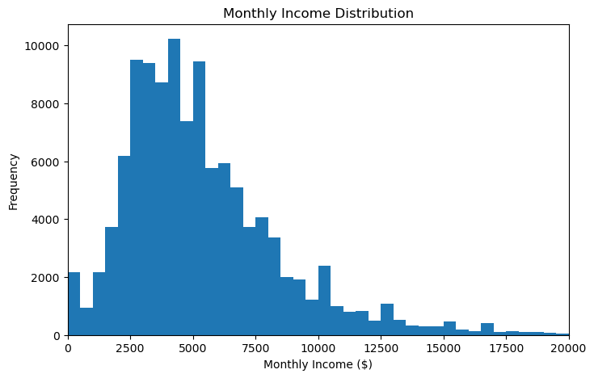

```python
#Creating a Histogram to show the distribution of the Stated Monthly Income
plt.figure(figsize = [8, 5])
#Histogram with dynamic number of bins
bin = np.arange(0,  loan_subset['StatedMonthlyIncome'].max()+500, 500)
plt.hist(data =  loan_subset, x = 'StatedMonthlyIncome', bins = bin)
plt.xlim(0, 20000);
label('Monthly Income ($)', 'Frequency', 'Monthly Income Distribution');
```

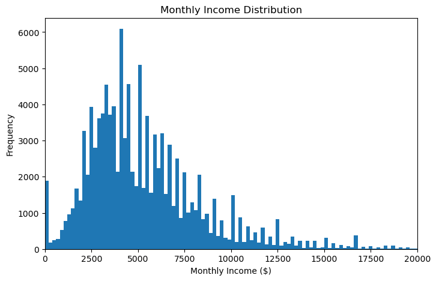

```python
#Further investigation with samller binsize
plt.figure(figsize = [8, 5])
#Histogram with dynamic number of bins
bin = np.arange(0,  loan_subset['StatedMonthlyIncome'].max()+200, 200)
plt.hist(data =  loan_subset, x = 'StatedMonthlyIncome', bins = bin)
plt.xlim(0, 20000);
label('Monthly Income ($)', 'Frequency', 'Monthly Income Distribution');
```

- The distribution clearly shows that the majority of the borrowers earn between 2500k to 7500k. When compared to the other range of monthly income, it can be deduced that they are low-income earners. The distribution or plot is right skewed.

**What is the Loan Amount distribution?**

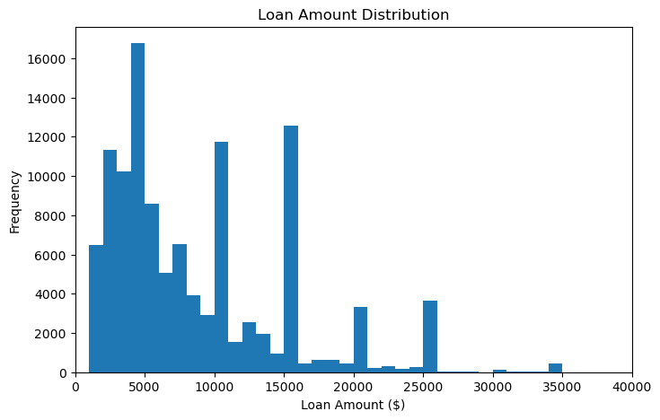

```python
#Creating a Histogram to show the distribution of the 'LoanOriginalAmount'
plt.figure(figsize = [8, 5])
#Histogram with dynamic number of bins
bin = np.arange(0,  loan_subset['LoanOriginalAmount'].max()+1000, 1000)
plt.hist(data =  loan_subset, x = 'LoanOriginalAmount', bins = bin)
plt.xlim(0, 40000);
label('Loan Amount ($)', 'Frequency', 'Loan Amount Distribution');
```

- The majority of borrowers took loans of 5k, and the loan amount is spread across 5k to 35k. However, the peak values are 5k, 10k, 15k, 20k, and 25k.

**What is the lenght of employment distribution?**

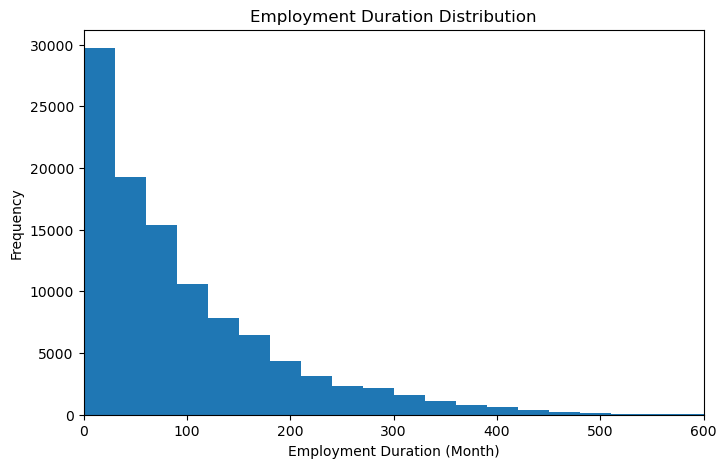

```python
#Creating a Histogram to show the distribution of Employment Duration
plt.figure(figsize = [8, 5])
#Histogram with dynamic number of bins
bin = np.arange(0, loan_subset['EmploymentStatusDuration'].max()+30, 30)
plt.hist(data =  loan_subset, x = 'EmploymentStatusDuration', bins = bin)
plt.xlim(0, 600);
label('Employment Duration (Month)', 'Frequency', 'Employment Duration Distribution');
```

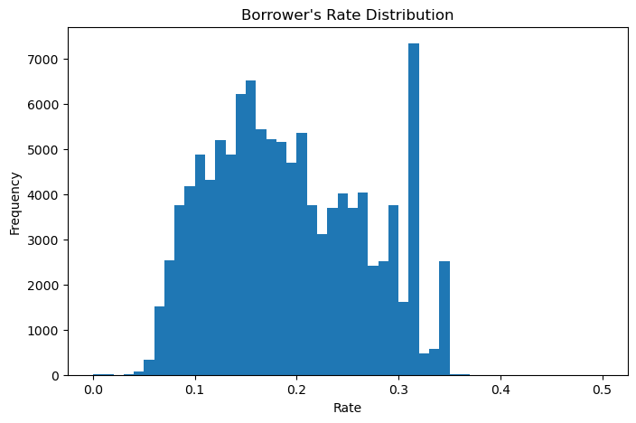

```python
#Creating a Histogram to show the distribution of Borrower's Rate
plt.figure(figsize = [8, 5])
#Histogram with dynamic number of bins
bin = np.arange(0, loan_subset['BorrowerRate'].max()+0.01, 0.01)
plt.hist(data =  loan_subset, x = 'BorrowerRate', bins = bin)
label('Rate', 'Frequency', "Borrower's Rate Distribution");
```

**What is the loan payment distribution?**

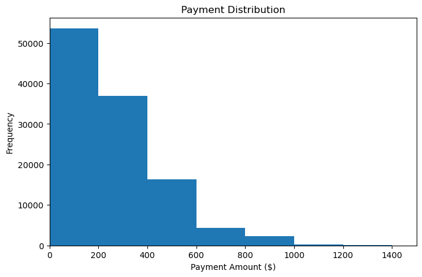

```python
#Creating a Histogram to show the distribution of Monthly Loan Payment
plt.figure(figsize = [8, 5])
#Histogram with dynamic number of bins
bin = np.arange(0, loan_subset['MonthlyLoanPayment'].max()+200, 200)
plt.hist(data =  loan_subset, x = 'MonthlyLoanPayment', bins = bin)
plt.xlim(0, 1500);
label('Payment Amount ($)', 'Frequency', 'Payment Distribution');
```

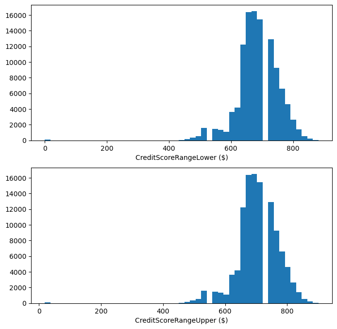

```python
#Creating a Histogram using subplot to show the distribution of upper and lower credit score range
fig, ax = plt.subplots(nrows = 2, figsize = [8, 8])

variables = ['CreditScoreRangeLower', 'CreditScoreRangeUpper']
for i in range(len(variables)):
    var = variables[i]
    bins = np.arange(min(loan_subset[var]), max(loan_subset[var])+18, 18)
    ax[i].hist(data = loan_subset, x = var, bins = bins)
    ax[i].set_xlabel('{} ($)'.format(var))

plt.show()
```

- The distribution of CreditScoreRangeLower is similar to CreditScoreRangeUpper.

**What state has the highest number of borowers?**

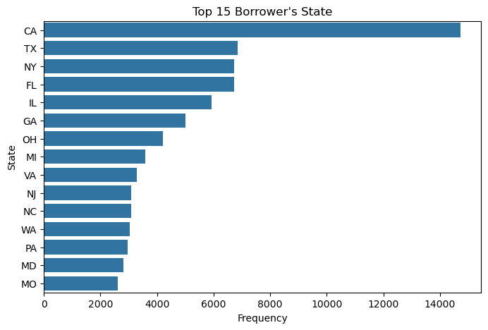

```python
#Creating a horizontal barchart to show the demography of Borrower's
plt.figure(figsize = [8, 5])
#Selecting the first color from seaborn's color palette
base_color = sb.color_palette()[0]
#To order the bar programmatically
state_order = loan_subset['BorrowerState'].value_counts().iloc[:15].index
# Use the `color` and 'order' argument
sb.countplot(data =  loan_subset, y = 'BorrowerState', color = base_color, order = state_order)
label('Frequency', 'State', "Top 15 Borrower's State");
```

- The state of California has the highest number of borrowers.

**What month is loan most issued?**

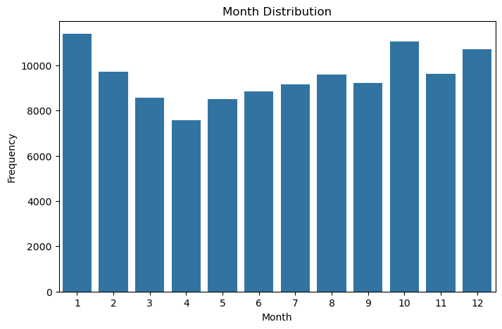

```python
#Creating a barchart to show Month distribution
def loan_month_plot():
    #Convert LoanOriginationDate to Datetime
    loan_subset['LoanOriginationDate'] = pd.to_datetime(loan_subset.LoanOriginationDate)
    #Extracting month from the 'LoanOriginationDate' variable
    loan_subset['Month'] = loan_subset['LoanOriginationDate'].dt.month
    #Plotting
    plt.figure(figsize = [8, 5])
    base_color = sb.color_palette()[0]
    sb.countplot(data = loan_subset, x = 'Month', color = base_color)
    label('Month', 'Frequency', 'Month Distribution');

loan_month_plot()
```

- January is the month with the highest number of borrowers, followed closely by October and December. It is understandable considering the festivity or celebration around that period.

**What year has the highest number of borrowers?**

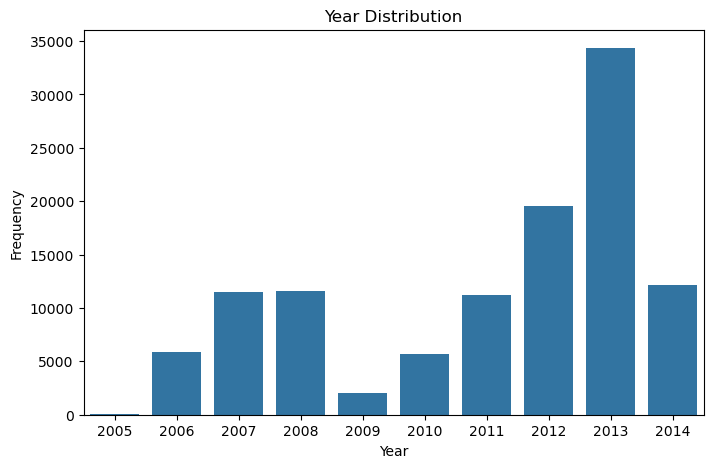

```python
#A bar chart showing the distribution of years
def loan_year_plot():
    #Convert LoanOriginationDate to Datetime and extracting year
    loan_subset['Year'] = pd.DatetimeIndex(loan_subset['LoanOriginationDate']).year

    plt.figure(figsize = [8, 5])
    base_color = sb.color_palette()[0]

    #To convert Year into ordinal variable
    year_order = [2005, 2006, 2007, 2008, 2009, 2010, 2011, 2012, 2013, 2014]
    sb.countplot(data = loan_subset, x = 'Year', color = base_color, order = year_order)
    label('Year', 'Frequency', 'Year Distribution');

loan_year_plot()
```

- The distribution clearly shows that the year 2013 has the highest number of borrowers

**What is the duration of the loan?**

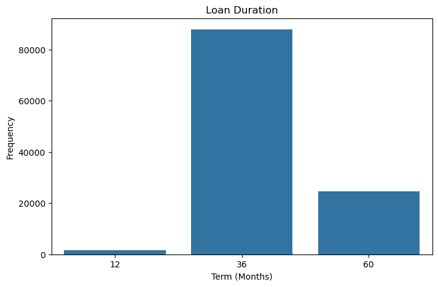

```python
#A barchart showing the distribution of Term
plt.figure(figsize = [8, 5])
base_color = sb.color_palette()[0]
sb.countplot(data = loan_subset, x = 'Term', color = base_color)
label('Term (Months)', 'Frequency', 'Loan Duration');
```

- The Term, i.e, length of time to pay back the loans (loan duration) for the majority of the borrowers is thirty-six months.

**What is the occupation of majority of the borrower?**

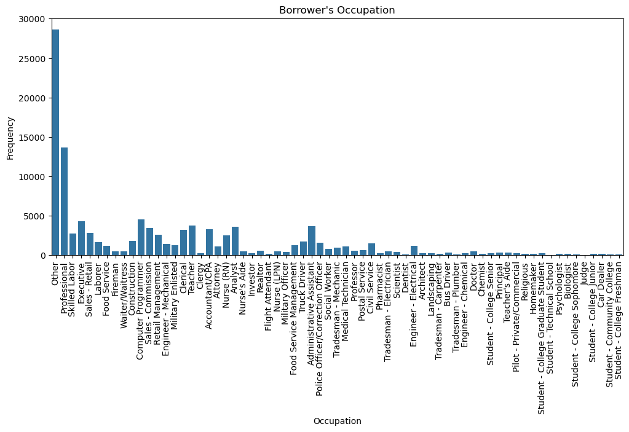

```python
#A barchart showing the occupation of the borrower
plt.figure(figsize = [12, 5])
base_color = sb.color_palette()[0]
sb.countplot(data = loan_subset, x = 'Occupation', color = base_color)
plt.xticks(rotation = 90);
label('Occupation', 'Frequency', "Borrower's Occupation");
```

- The predominant occupation of the borrowers is termed 'other'.

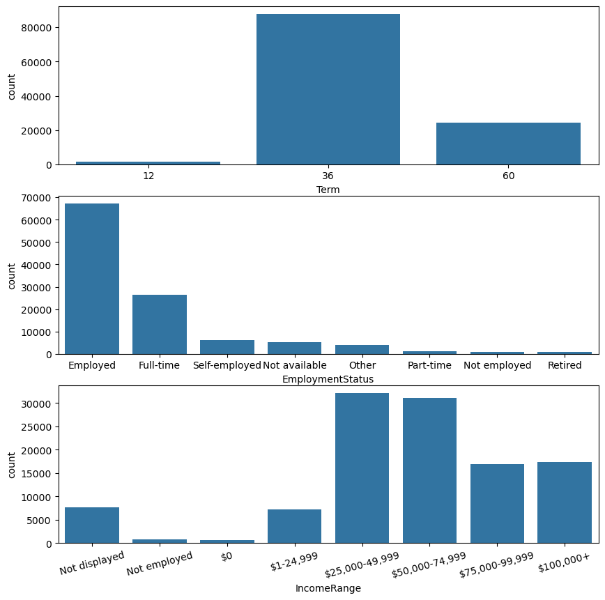

```python
#Plotting some categorical variables simultaneously.

fig, ax = plt.subplots(nrows = 3, figsize = [10,10])
base_color = sb.color_palette()[0]

sb.countplot(data = loan_subset, x = 'Term', color = base_color, ax = ax[0])
sb.countplot(data = loan_subset, x = 'EmploymentStatus',  order = loan_subset['EmploymentStatus'].value_counts().index,
             color = base_color, ax = ax[1])
sb.countplot(data = loan_subset, x = 'IncomeRange', color = base_color, ax = ax[2])
plt.xticks(rotation = 15);

plt.show()
```

- The majority of the borrowers have an IncomeRange between 25k - 49.999k. While the EmploymentStatus of most of the borrowers is 'Employed'

#### Of the features you investigated, were there any unusual distributions? Did you perform any operations on the data to tidy, adjust, or change the form of the data? If so, why did you do this?

I had to extract the year and month the loan was given from the LoanOriginationDate variable in order to know the year and month that had the highest number of borrowers.

The occupation of the highest number of borrowers that accessed the loan seemed odd to me. Because pretty much almost every profession was covered by the various designation. My deduction is that the 'Other' could be jobless or doing nothing significant.

#### 4. Bivariate Exploration

In this section, I'd investigate relationships between pairs of these variables, particularly how each of them relates to borrowers.

```python
#Grouping some numerical and categorical variables present in the subset data.
numerical_vars = ['LoanOriginalAmount', 'StatedMonthlyIncome', 'EmploymentStatusDuration', 'Term', 'BorrowerRate', 'MonthlyLoanPayment']
categorical_vars = ['Occupation', 'Year', 'IsBorrowerHomeowner', 'IncomeRange', 'EmploymentStatus']
```

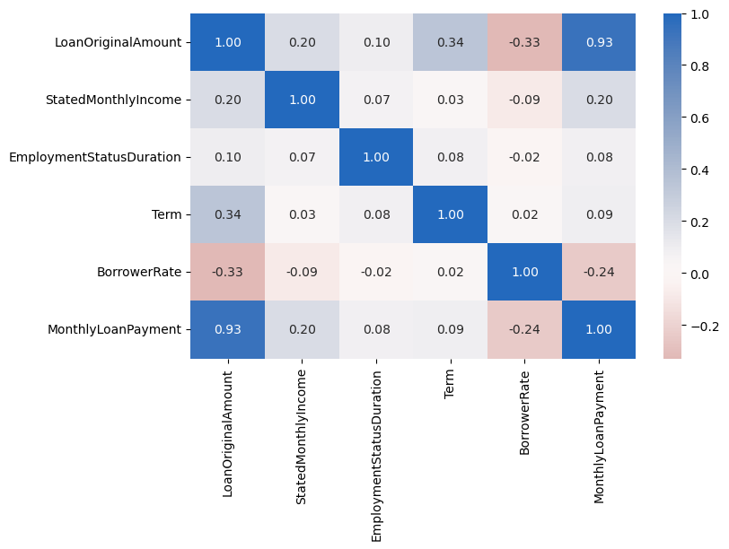

```python
#Correlation of numerical variables using heat map
plt.figure(figsize = [8, 5])
sb.heatmap(loan_subset[numerical_vars].corr(), annot = True, fmt = '.2f',
           cmap = 'vlag_r', center = 0)
plt.show()
```

- The correlation between LoanOriginalAmount and StatedMonthlyIncome is 0.20. A weak positive correlation.
- The correlation between LoanOriginalAmount and MonthlyLoanPayment is 0.93, a positive correlation. It suggests the majority of the borrowers are consistent with their payments.
- The correlation between LoanOriginalAmount and BorrowerRate is -0.33. A negative correlation

**Plotting a combination of scatter plot and histogram for the numerical variables**

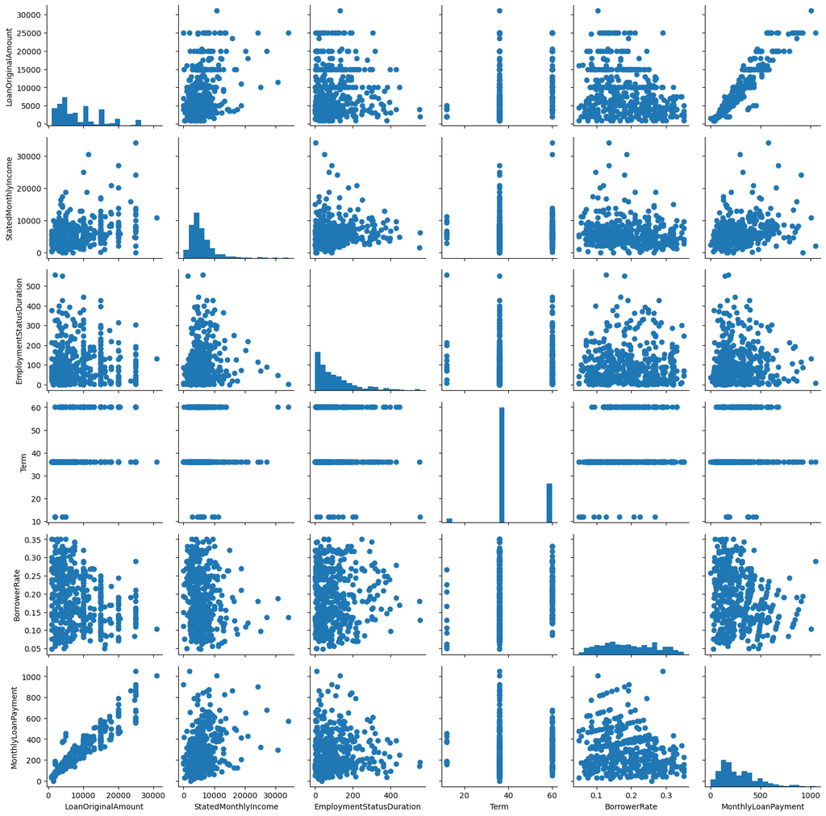

```python
#A matrix of 500 sample of the loan_subset dataframe so that the plots are clearer and rendered faster
samples = np.random.choice(loan_subset.shape[0], 500, replace = False)
loan_samp = loan_subset.loc[samples,:]

g = sb.PairGrid(data = loan_samp, vars = numerical_vars)
g = g.map_diag(plt.hist, bins = 20);
g.map_offdiag(plt.scatter)
```

- A positive correlation exists from the matrix between MonthlyLoanPayment and LoanOriginalAmount
- The BorrowerRate has a negative relationship with LoanOriginalAmount

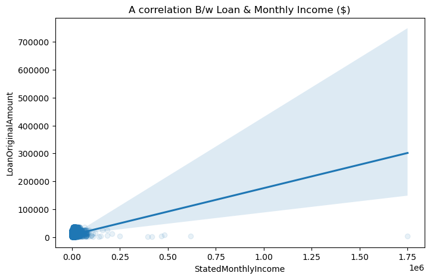

```python
#A scatterplot showing the correlation between Loan vs Monthly Income
plt.figure(figsize = [8, 5]);
sb.regplot(data = loan_subset, x = 'StatedMonthlyIncome', y = 'LoanOriginalAmount', x_jitter = 0.3,
           scatter_kws = ({'alpha':1/10}));
plt.title('A correlation B/w Loan & Monthly Income ($)');
```

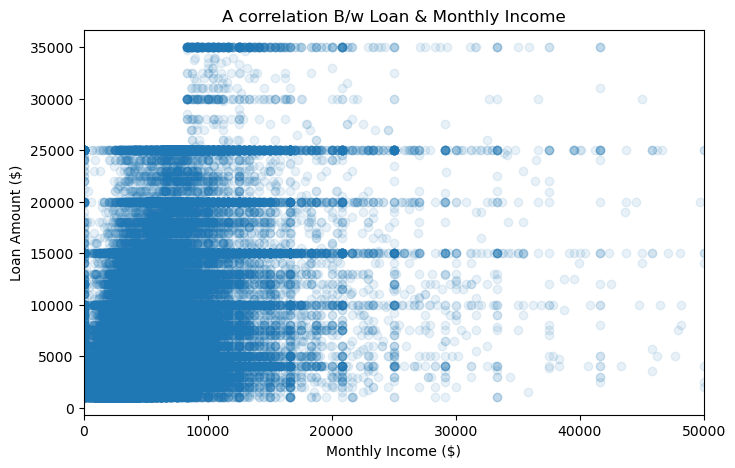

```python
#Investigating further with limit on the x-axis
plt.figure(figsize = [8, 5])
plt.scatter(data = loan_subset, x = 'StatedMonthlyIncome', y = 'LoanOriginalAmount', alpha = 1/10)
plt.xlim(0, 50000);
label('Monthly Income ($)', 'Loan Amount ($)', 'A correlation B/w Loan & Monthly Income');
```

- The majority of the borrowers earning around 10k accessed a loan amount almost twice their monthly Income.

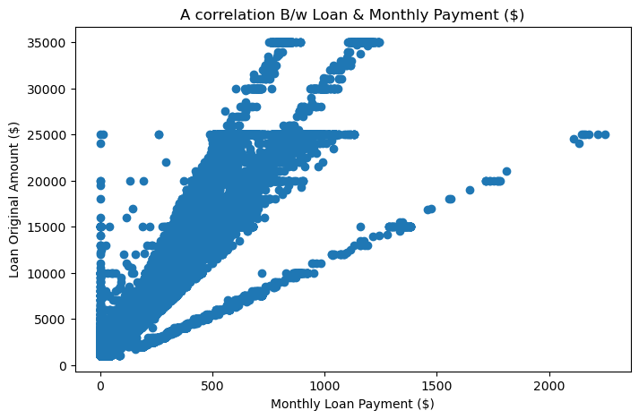

```python
#A scatterplot showing the correlation between LoanOriginalAmount vs. MonthlyLoanPayment
plt.figure(figsize = [8, 5])
plt.scatter(data = loan_subset, x = 'MonthlyLoanPayment', y = 'LoanOriginalAmount')
label('Monthly Loan Payment ($)', 'Loan Original Amount ($)', 'A correlation B/w Loan & Monthly Payment ($)');
```

- There is a strong positive relationship between Loan Amount and Monthly Loan Payment. It suggests that borrowers are committed and consistent in loan payment

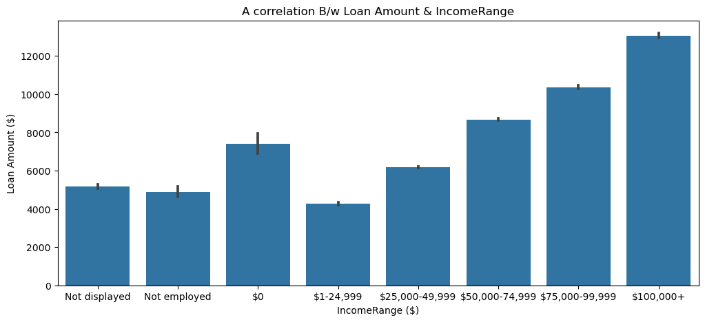

```python
# A barplot showing the correlation between Loan Amount and IncomeRange
plt.figure(figsize = [12, 5])
base_color = sb.color_palette()[0]
sb.barplot(data = loan_subset, x ='IncomeRange', y = 'LoanOriginalAmount', color = base_color)
label('IncomeRange ($)', 'Loan Amount ($)', 'A correlation B/w Loan Amount & IncomeRange');
```

- The borrower with the highest IncomeRange of 100k+ got to access a higher amount of loan. The higher your IncomeRange the higher the loan amount accessed.

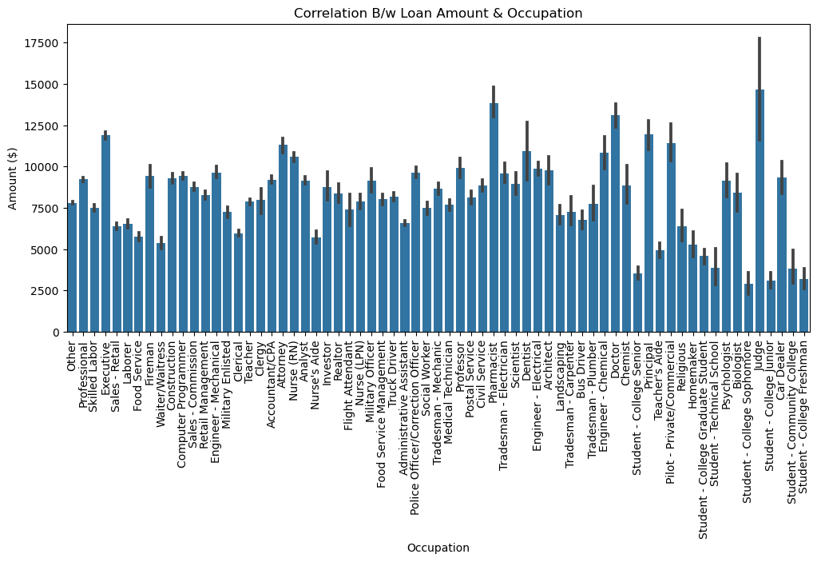

```python
#A barplot showing the correlation between Loan Amount and occupation
plt.figure(figsize = [12, 5])
base_color = sb.color_palette()[0]
sb.barplot(data = loan_subset, x ='Occupation', y = 'LoanOriginalAmount', color = base_color)
plt.xticks(rotation = 90);
label('Occupation', 'Amount ($)', 'Correlation B/w Loan Amount & Occupation');
```

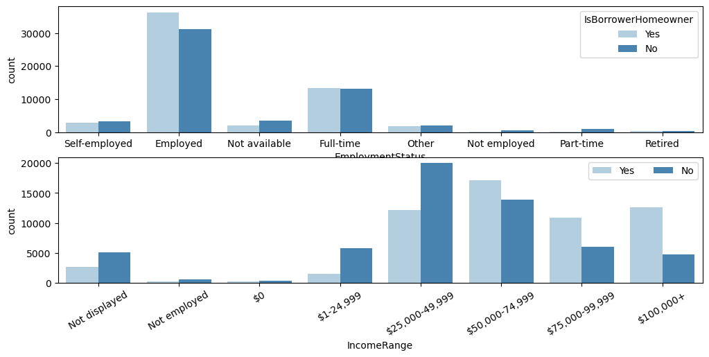

```python
#Using Subplot to investigate the relationship between two categoriacal variables

#Converting boolean to string
loan_subset['IsBorrowerHomeowner'] = loan_subset['IsBorrowerHomeowner'].map({True: 'Yes', False: 'No'})

#Subplot 1: EmploymentStatus vs. IsBorrowerHomeowner
plt.figure(figsize = [12, 8])
ax = plt.subplot(3, 1, 1)
sb.countplot(data = loan_subset, x = 'EmploymentStatus', hue = 'IsBorrowerHomeowner', palette = 'Blues')

#Subplot 2: IncomeRange vs. IsBorrowerHomeowner
ax = plt.subplot(3, 1, 2)
sb.countplot(data = loan_subset, x = 'IncomeRange', hue = 'IsBorrowerHomeowner', palette = 'Blues')
plt.xticks(rotation = 30)
ax.legend(ncol = 2)
```

- The majority of the borrowers have an IncomeRange between 25k - 49.999k, and they do not own their homes.

#### Did you observe any interesting relationships between the other features (not the main feature(s) of interest)?

Most 'Employed' borrowers own their homes while the borrowers with the highest IncomeRange of 100k+ also own their homes.

#### 5. Multivariate Exploration

Creating plots of three or more variables to investigate the data even further.

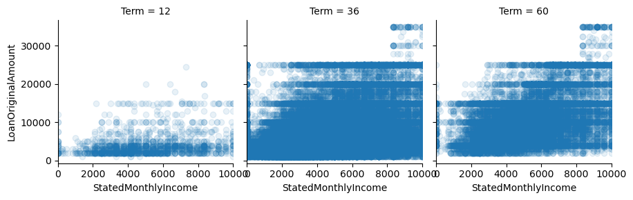

```python
#A relationship between LoanOriginalAmount, StatedMonthlyIncome and Term
g = sb.FacetGrid(data = loan_subset, col = 'Term')
g.map(plt.scatter, 'StatedMonthlyIncome', 'LoanOriginalAmount', alpha = 0.1)
g.add_legend()
plt.xlim(0, 10000);
```

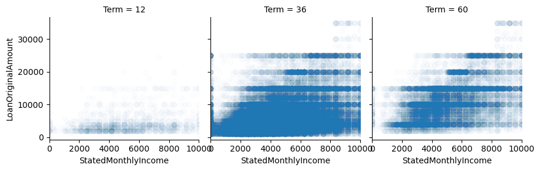

```python
#Investigating further with increased transparency
g = sb.FacetGrid(data = loan_subset, col = 'Term')
g.map(plt.scatter, 'StatedMonthlyIncome', 'LoanOriginalAmount', alpha = 0.01)
g.add_legend()
plt.xlim(0, 10000);
```

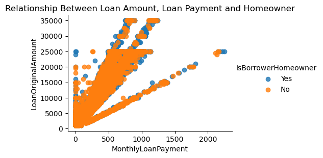

```python
#Investigating into the relationship b/w LoanOriginalAmount, MonthlyLoanPayment & IsBorrowerHomeowner
g = sb.FacetGrid(data = loan_subset, hue = 'IsBorrowerHomeowner', aspect = 1.5)
g.map(sb.regplot, 'MonthlyLoanPayment', 'LoanOriginalAmount', x_jitter = 0.04, fit_reg = False);
plt.title('Relationship Between Loan Amount, Loan Payment and Homeowner')
g.add_legend();
```

#### Were there any interesting or surprising interactions between features?

The variables or features investigated pretty much reinforce the insights already generated.

#### 6. Conclusion

The dataset for this analysis was directly downloaded into Pandas dataframe, and afterward, it was assessed. I had to pick a few variables of interest to investigate because the number of variables was much. Having made a subset of the variables I was interested in, I started investigating the variables by doing a univariate exploration.

Doing a bivariate analysis or exploration also threw up a few insights. The borrowers that accessed higher loans were found to have a higher IncomeRange ranging between 75k - 100K+, and there is a positive correlation between the loan amount accessed and payment.

**Note**: One of the challenges encountered was having to choose which features to focus on because there were too many variables to choose from. I also heavily relied on the codes from Udacity classroom and a few from Google for this project.